# Using R to Analyse and Visualize Data - A Hands-on Workshop

Evan Cortens and Stephen Childs

October 20, 2019

# Introductions

## Introductions

- Who are you/where do you work?
- What software/tools do you spend most time with? (Excel? SPSS? Tableau? etc)
- Do you have any programming experience? (Python? C? Javascript?)
- What do you hope to get out of this workshop? How do you see yourself using R in an IR environment?

# Why use R?

## Why use R?

- Free
- Open-source
- A “statistical” programming language
  - Generally accepted by academic statisticians
  - Thoroughly grounded in statistical theory
- A great community
  - Help and support
  - Innovation and development
- R is a stable, well-supported language
  - Major corporate backing, e.g., Microsoft

## Growing fast!

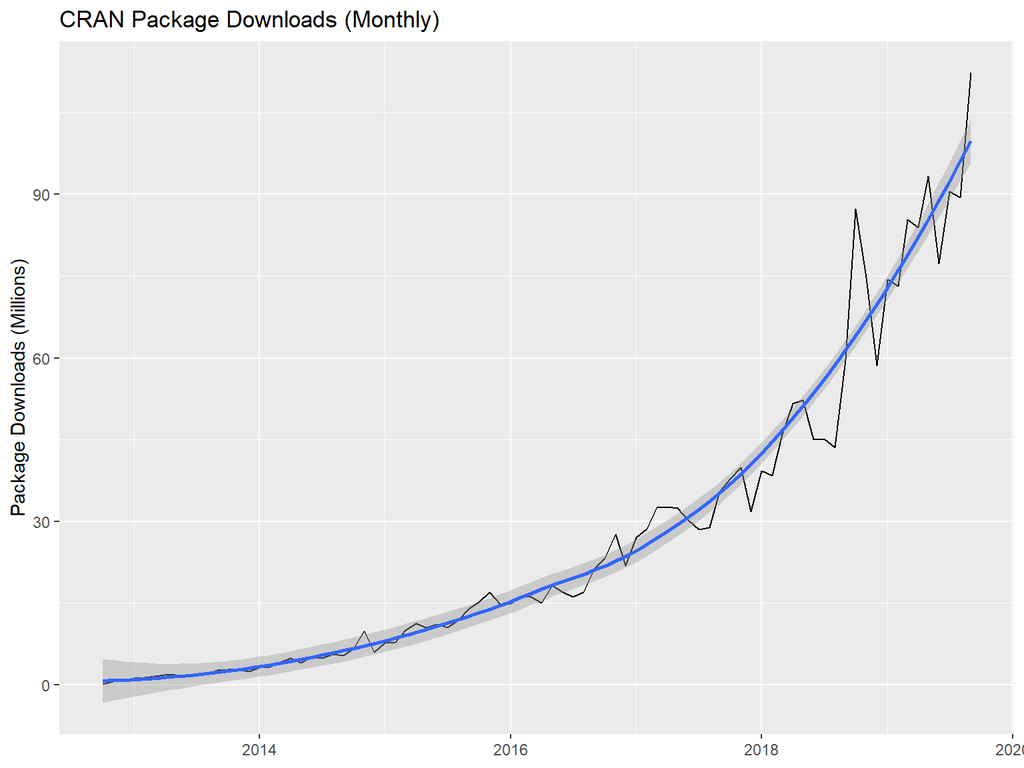

https://stackoverflow.blog/2017/10/10/impressive-growth-r/

## Some history

- Based on the S programming language
  - Dates from the late 1970s, substantially revised in the late 1980s
  - (there is still a commercial version, S-PLUS)
- R was developed at the University of Auckland
  - Ross Ihaka and Robert Gentleman
  - First developed in 1993
  - Stable public release in 2000
- RStudio
  - IDE, generally recognized as high quality, even outside R
  - Development began in 2008, first public release in February 2011
    - Version 1.0 in Fall 2016
  - There have been other IDEs for R in the past, but since RStudio came on the scene, most are no longer seriously maintained

## Some history

Why is this relevant?

- You’ll likely notice some quirks in R that differ from other programming languages you make have worked in–the unique history often explains why.
- Explains R’s position as a “statistical programming language”:
  - Think stats/data first, programming second.

# Today’s approach/Learning outcomes

## Import

- Loading the data!
- For IR-type tasks, this will generally be from data files or directly from databases.
- Other possibilities include web APIs, or even web scraping

## Tidy

- “Tidy data” (Wickham, 2014)
  - Each column is a variable, each row is an observation.
- Doing this kind of work up front, right after loading, lets you focus on the modelling/analysis/visualization problem at hand, rather than having to rework your data at each stage of your analysis.

## Transform/Visualize/Model

- Repeat these three steps as necessary:

## Transform

- Together with tidying, sometimes called *data wrangling*
  - Filtering (selecting specific observations)
  - Mutating (creating new variables)
  - Summarizing (means, counts, etc)

## Visualise

- For both exploratory purposes and production/communication

## Model

- Complementary to visualisation
- For the “precise exploration” of “specific questions”

## Communicate

- The final output, whether it’s just for yourself, your colleagues, or a wider audience
- Increasingly, there’s a trend toward “reproducible research” which integrates even the communciation step (final paper, report, etc) into the code/analysis.

# Housekeeping

## Installing R and RStudio

- https://cran.r-project.org/
- https://www.rstudio.com/products/rstudio/download3/#download
- `install.packages('tidyverse')`

## Basic R

- An interpreted language
- Code can be run as:
  - scripts (programatically/non-interactively)
  - from the prompt (interactively)
- R uses an REPL (Read-Evaluate-Print Loop)
  - Using R as a calculator (demonstration)

# Outline

## Outline

1. Visualisation
2. Transformation
3. Importing and ‘wrangling’
4. Hands-on portion using what we’ve learned

# Visualisation

## Let’s load our package

```r
library(tidyverse)
```

A package only needs to be *installed* once (per major version, e.g. 3.5.x to 3.6.x), but must be *loaded* every time.

## The ‘mpg’ data set

Data on the fuel efficiency of 38 models of cars between 1999 and 2008 from the US EPA:

```r
mpg
```

```
## # A tibble: 234 x 11
##    manufacturer model      displ  year   cyl trans drv     cty   hwy fl    class
##    <chr>        <chr>      <dbl> <int> <int> <chr> <chr> <int> <int> <chr> <chr>
##  1 audi         a4           1.8  1999     4 auto~ f        18    29 p     comp~
##  2 audi         a4           1.8  1999     4 manu~ f        21    29 p     comp~
##  3 audi         a4           2    2008     4 manu~ f        20    31 p     comp~
##  4 audi         a4           2    2008     4 auto~ f        21    30 p     comp~
##  5 audi         a4           2.8  1999     6 auto~ f        16    26 p     comp~
##  6 audi         a4           2.8  1999     6 manu~ f        18    26 p     comp~
##  7 audi         a4           3.1  2008     6 auto~ f        18    27 p     comp~
##  8 audi         a4 quattro   1.8  1999     4 manu~ 4        18    26 p     comp~
##  9 audi         a4 quattro   1.8  1999     4 auto~ 4        16    25 p     comp~
## 10 audi         a4 quattro   2    2008     4 manu~ 4        20    28 p     comp~
## # ... with 224 more rows
```

## The Grammar of Graphics

- Layers
- Inheritance
- Mapping (`aes`)

## Our First Plot

- A car’s highway mileage (mpg) vs its engine size (displacement in litres).
- What might the relationship be?

## Our First Plot

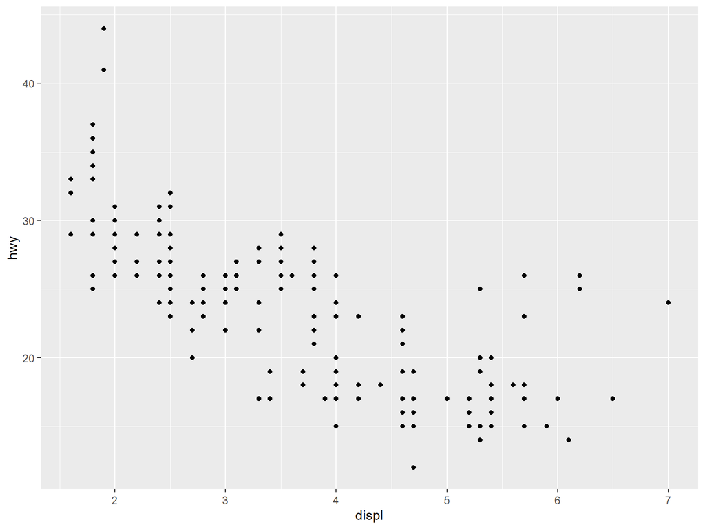

```r
ggplot(data = mpg) +
  geom_point(mapping = aes(x = displ, y = hwy))
```

- As engine size increases, fuel efficiency decreases, roughly.

## Exercises

- The first scatterplot was highway mileage vs displacement: how can we make it city mileage vs displacement?
- Make a scatterplot of `hwy` vs `cyl`.
- What about a scatterplot of `class` vs `drv`?

## Hwy vs cyl

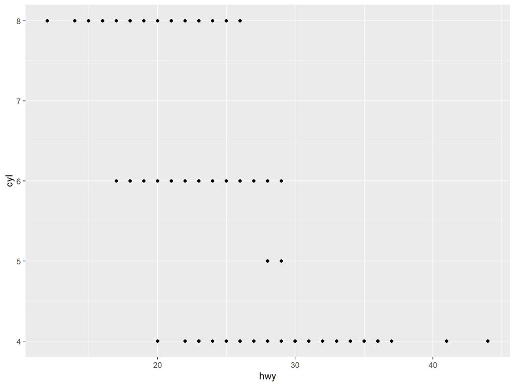

```r
ggplot(data = mpg) +
  geom_point(mapping = aes(x = hwy, y = cyl))
```

## Class vs drv

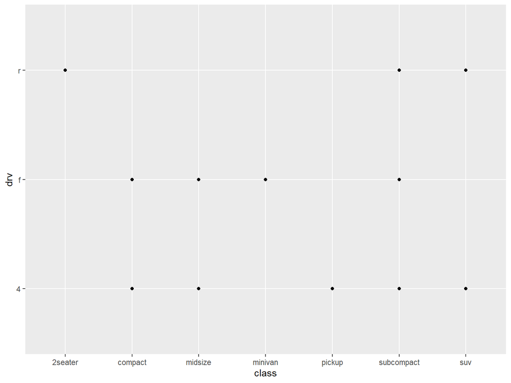

```r
ggplot(data = mpg) +
  geom_point(mapping = aes(x = class, y = drv))
```

What’s going on here? Is this useful? How might we make it more useful?

## Additional aesthetics

What about those outliers? Use the `color` aesthetic.

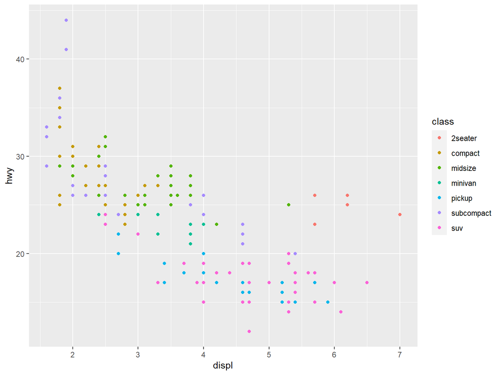

```r
ggplot(data = mpg) +
  geom_point(mapping = aes(x = displ, y = hwy, color = class))
```

## ‘Unmapped’ aesthetics

What’s happening here?

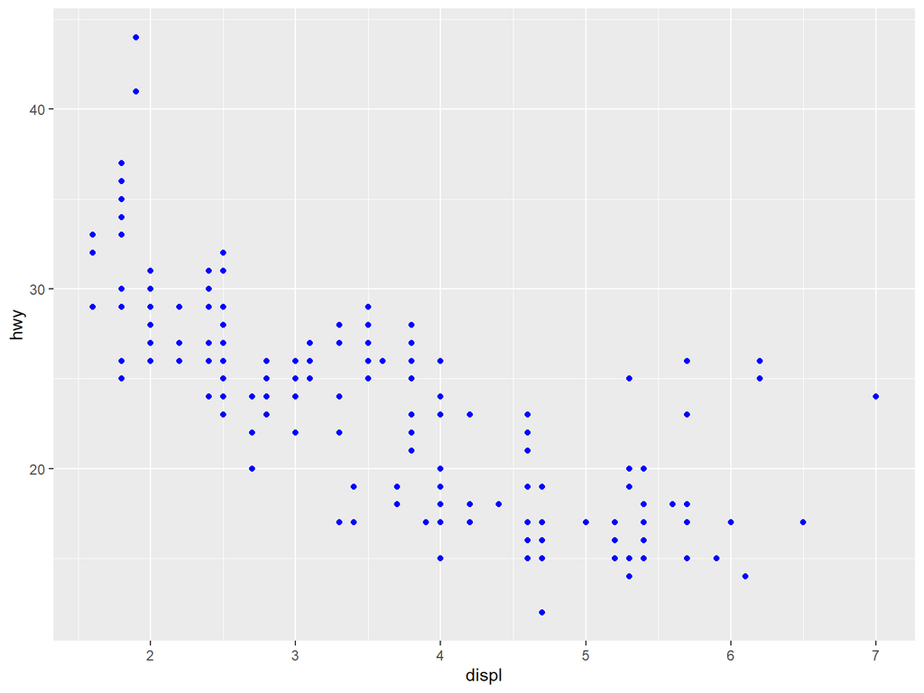

```r
ggplot(data = mpg) +
  geom_point(mapping = aes(x = displ, y = hwy), color = "blue")
```

## What’s gone wrong?

What’s happened here? What colour are the points? Why?

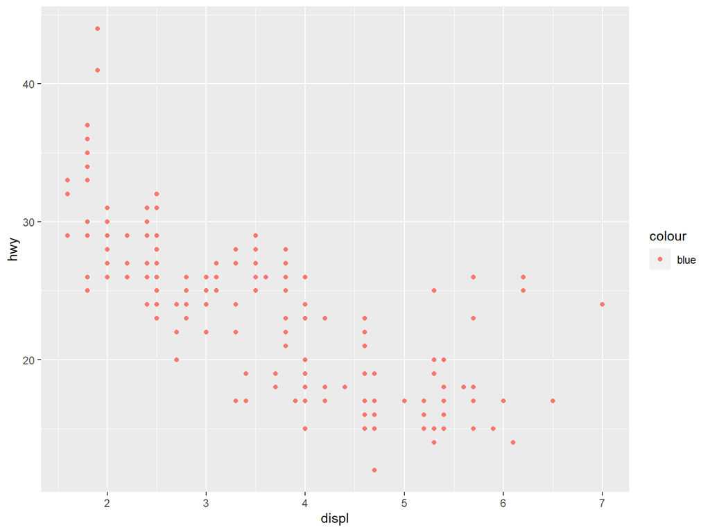

```r
ggplot(data = mpg) +
  geom_point(mapping = aes(x = displ, y = hwy, color = "blue"))
```

## Exercises

- `mpg` variable types: which are categorical, which are continuous?
- `?mpg`
- Map a continuous variable to colour, size, and shape: how are these aesthetics different for categorical vs continuous?
- What happens if you map an aesthetic to something other than a variable name, like `aes(color = displ < 5)`?

## Facets: One Variable

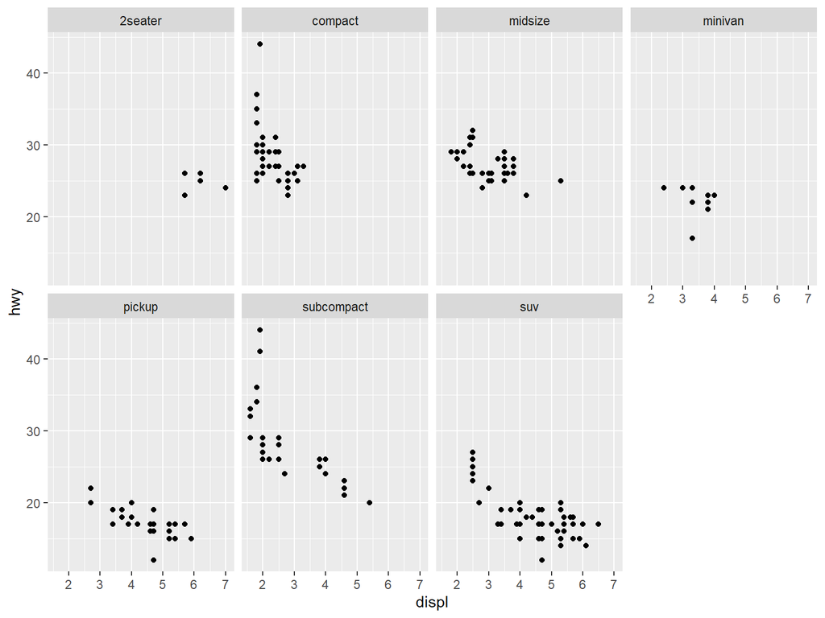

```r
ggplot(data = mpg) +
  geom_point(mapping = aes(x = displ, y = hwy)) +
  facet_wrap(~ class, nrow = 2)
```

## Facets: Two Variables

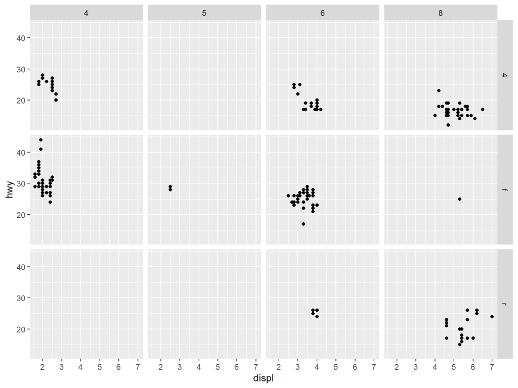

```r
ggplot(data = mpg) +
  geom_point(mapping = aes(x = displ, y = hwy)) +
  facet_grid(drv ~ cyl)
```

## Other “geoms” (geometries)

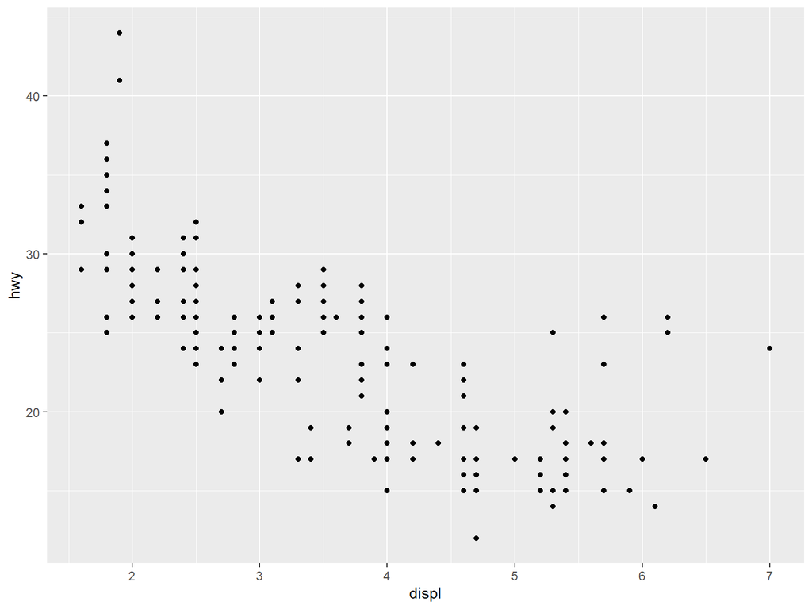

```r
ggplot(data = mpg) +
  geom_point(mapping = aes(x = displ, y = hwy))
```

## Smooth

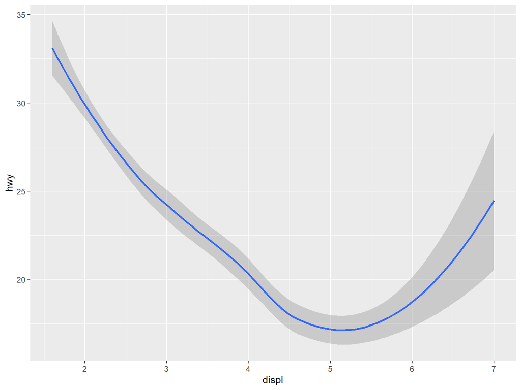

```r
ggplot(data = mpg) +
  geom_smooth(mapping = aes(x = displ, y = hwy))
```

## Smooth aesthetics

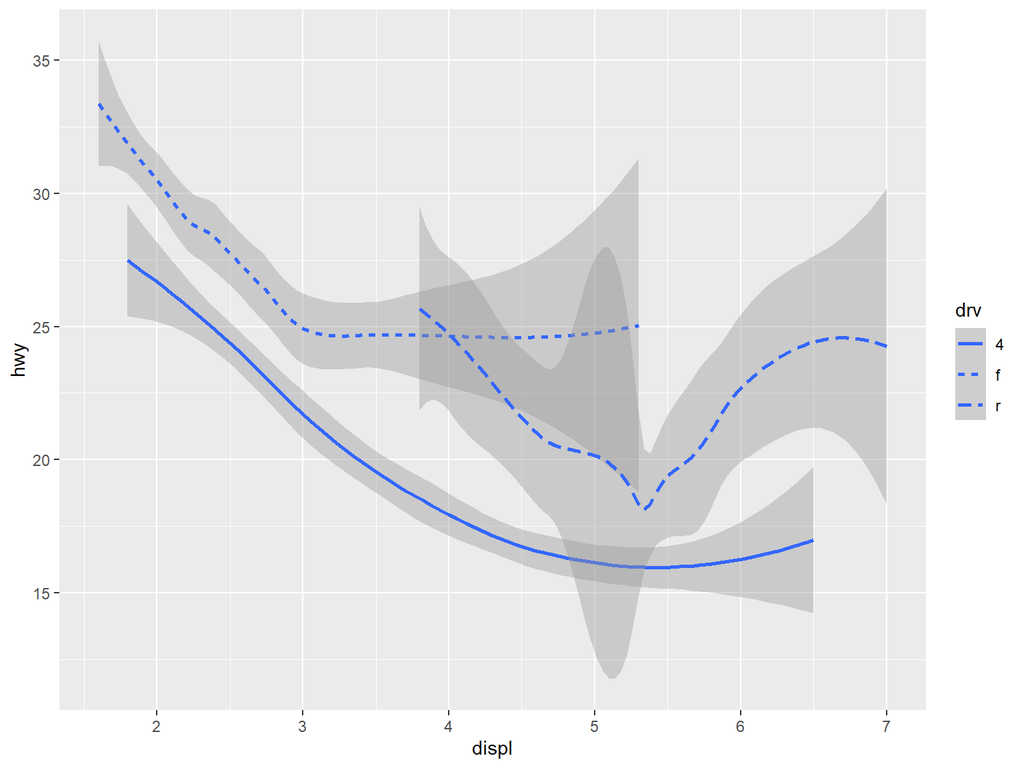

```r
ggplot(data = mpg) +
  geom_smooth(mapping = aes(x = displ, y = hwy, linetype = drv))
```

## Which aesthetics do geoms have?

`?geom_smooth`

## Clearer?

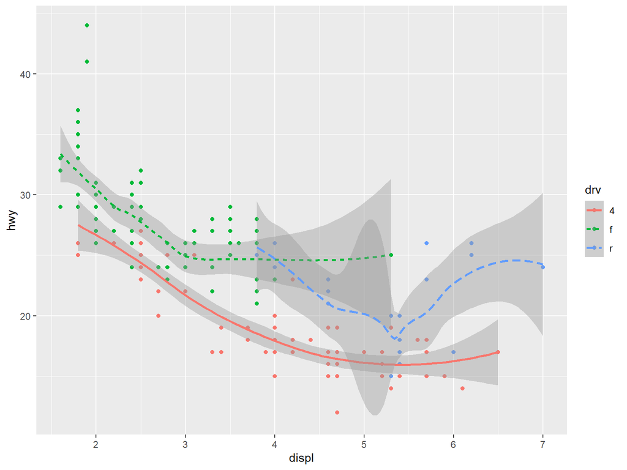

```r
ggplot(data = mpg) +
  geom_point(mapping = aes(x = displ, y = hwy, color = drv)) +
  geom_smooth(mapping = aes(x = displ, y = hwy, color = drv, linetype = drv))
```

## Reducing Duplication

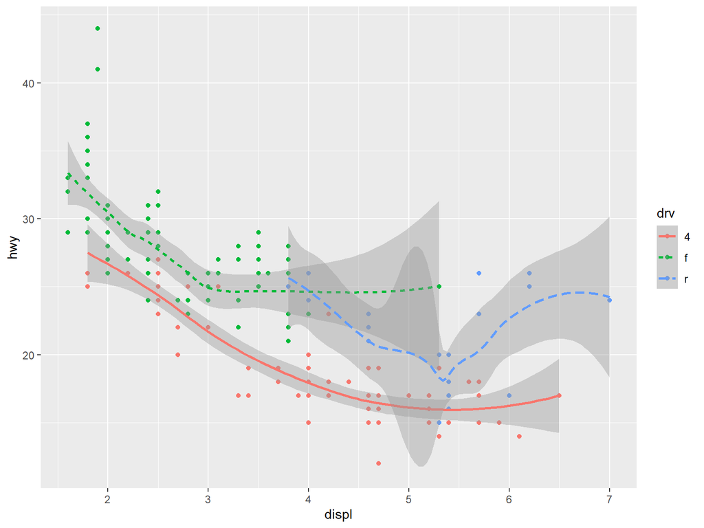

```r
ggplot(data = mpg, mapping = aes(x = displ, y = hwy, color = drv)) +
  geom_point() +
  geom_smooth(mapping = aes(linetype = drv))
```

## Exercise: Recreate:

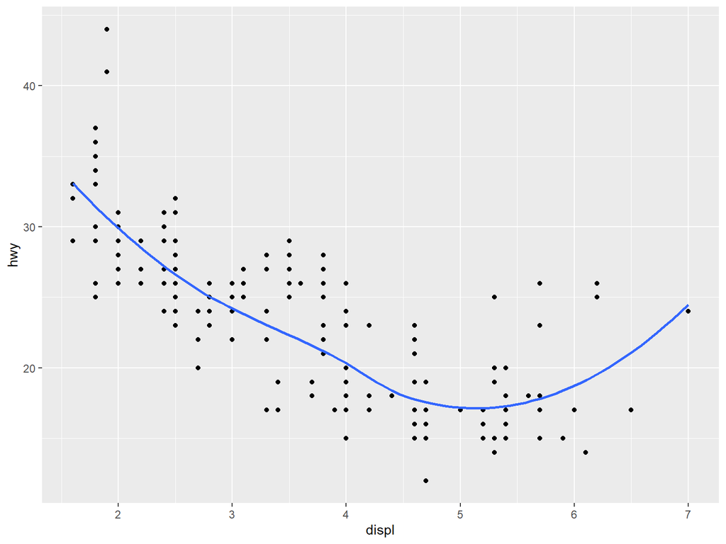

## Exercise: Recreate:

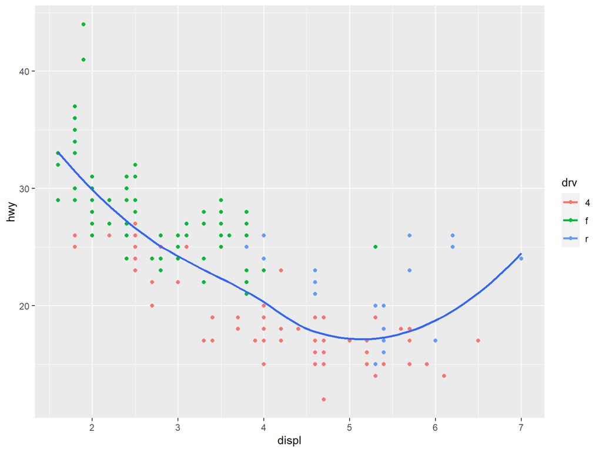

## Exercise: Recreate:

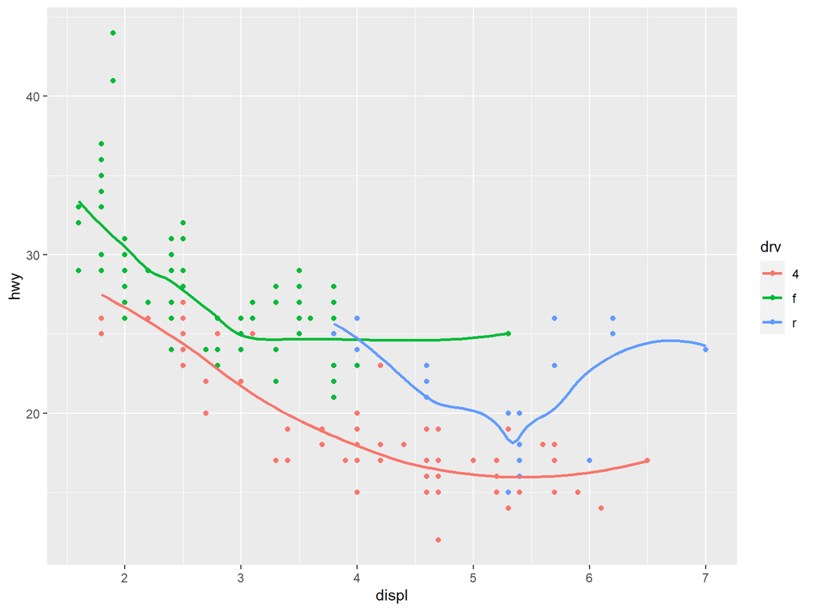

## One last visualization

A common scenario:

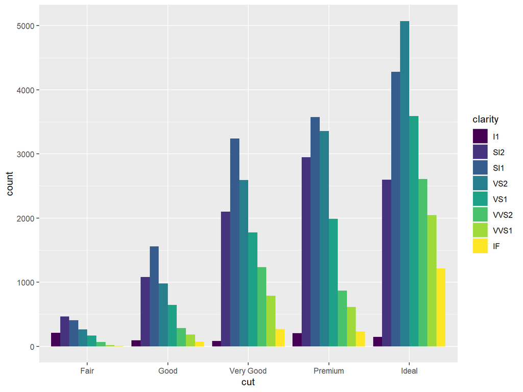

```r
ggplot(data = diamonds) +
  geom_bar(mapping = aes(x = cut, fill = clarity), position = "dodge")
```

# Coding basics

## R as a calculator

```r
1 / 200 * 30
```

```
## [1] 0.15
```

```r
(59 + 73 + 2) / 3
```

```
## [1] 44.66667
```

```r
sin(pi / 2)
```

```
## [1] 1
```

## Assignments

```r
x <- 3 * 4
```

## Calling functions

Calling R functions, in general:

```
function_name(arg1 = val1, arg2 = val2, ...)
```

An example function, `seq`:

```r
seq(1, 10)
```

```
##  [1]  1  2  3  4  5  6  7  8  9 10
```

# Data wrangling with `dplyr` and `tidyr` (`tidyverse`)

## Create RStudio project

1. File | New Project…
2. New Directory
3. Empty Project
4. Under “Directory name:” put in “CIRPA 2019”, under “Create project as a subdirectory of:”, pick somewhere you’ll remember.
5. Click “Create Project”, and RStudio will refresh, with your new project loaded.

## Download the data

We’ll look at CANSIM Tables 0477-0058 and 0477-0059 which cover university revenues and expenditures, respectively.

To save time, I’ve already downloaded the data from CANSIM. You can get it here:

http://evancortens.com/cirpa/

## Load the data

We’ll use `read_csv()` from `readr`, which I prefer to the base R function, as it has some more sensible defaults, and it’s faster.

```r
# https://www150.statcan.gc.ca/n1/en/tbl/csv/37100026-eng.zip
# make sure the zip file is in the same directory as your RStudio project

revenue_raw <- read_csv('http://evancortens.com/cirpa/04770058-eng.csv.gz')
```

## What does the data look like?

```r
revenue_raw
```

```
## # A tibble: 114,600 x 8
##    Ref_Date  GEO    SCHOOL         REVENUE   FUND       Vector Coordinate  Value
##    <chr>     <chr>  <chr>          <chr>     <chr>      <chr>  <chr>       <dbl>
##  1 2000/2001 Canada Total univers~ Total re~ Total fun~ v8070~ 1.1.1.1    1.62e7
##  2 2001/2002 Canada Total univers~ Total re~ Total fun~ v8070~ 1.1.1.1    1.72e7
##  3 2002/2003 Canada Total univers~ Total re~ Total fun~ v8070~ 1.1.1.1    1.85e7
##  4 2003/2004 Canada Total univers~ Total re~ Total fun~ v8070~ 1.1.1.1    2.16e7
##  5 2004/2005 Canada Total univers~ Total re~ Total fun~ v8070~ 1.1.1.1    2.27e7
##  6 2005/2006 Canada Total univers~ Total re~ Total fun~ v8070~ 1.1.1.1    2.47e7
##  7 2006/2007 Canada Total univers~ Total re~ Total fun~ v8070~ 1.1.1.1    2.65e7
##  8 2007/2008 Canada Total univers~ Total re~ Total fun~ v8070~ 1.1.1.1    2.72e7
##  9 2008/2009 Canada Total univers~ Total re~ Total fun~ v8070~ 1.1.1.1    2.64e7
## 10 2009/2010 Canada Total univers~ Total re~ Total fun~ v8070~ 1.1.1.1    3.19e7
## # ... with 114,590 more rows
```

## What does the data look like?

```r
View(revenue_raw) # in RStudio
```

Or click the icon in the `Environment` tab.

## What does the data look like?

```r
head(revenue_raw, 1) # show just the first row
```

- *Ref_Date*: fiscal year
- *GEO*: province or whole country
- *SCHOOL*: Direct participation in CAUBO survey, or via Statistics Canada, or combined (we’ll just look at this)
- *REVENUE*: Type of income (e.g., tuition, provincial government, SSHRC, etc)
- *FUND*: Classification of income “in accordance with activities or objectives as specified by donors, … regulations, restrictions, or limitations” (We’re just going to look at “Total funds (x 1,000)”, but the distinctions are important for full analysis)
- *Vector*: a CANSIM unique identifier
- *Coordinate*: ditto
- *Value*: the actual dollar value (x 1,000, per the FUND heading)

## What makes data “tidy”?

1. Each variable must have its own column.
2. Each observation must have its own row.
3. Each value must have its own cell.

(See Wickham, 2014 and *R for Data Science*, chapter 12)

Is the CANSIM data tidy?

- Nope! So let’s tidy it.

## dplyr basics

- Pick observations by their values (`filter()`).
- Reorder the rows (`arrange()`).
- Pick variables by their names (`select()`).
- Create new variables with functions of existing variables (`mutate()`).
- Collapse many values down to a single summary (`summarise()`).
- All can be used in conjunction with `group_by()`

## dplyr cheat sheet

[figure not shown]

https://www.rstudio.com/resources/cheatsheets/

(or Help | Cheatsheets in RStudio!)

## `filter()` the rows we want

```r
filter(revenue_raw,
       SCHOOL == 'Total universities and colleges',
       FUND == 'Total funds (x 1,000)')
```

```
## # A tibble: 5,280 x 8
##    Ref_Date  GEO    SCHOOL         REVENUE   FUND       Vector Coordinate  Value
##    <chr>     <chr>  <chr>          <chr>     <chr>      <chr>  <chr>       <dbl>
##  1 2000/2001 Canada Total univers~ Total re~ Total fun~ v8070~ 1.1.1.1    1.62e7
##  2 2001/2002 Canada Total univers~ Total re~ Total fun~ v8070~ 1.1.1.1    1.72e7
##  3 2002/2003 Canada Total univers~ Total re~ Total fun~ v8070~ 1.1.1.1    1.85e7
##  4 2003/2004 Canada Total univers~ Total re~ Total fun~ v8070~ 1.1.1.1    2.16e7
##  5 2004/2005 Canada Total univers~ Total re~ Total fun~ v8070~ 1.1.1.1    2.27e7
##  6 2005/2006 Canada Total univers~ Total re~ Total fun~ v8070~ 1.1.1.1    2.47e7
##  7 2006/2007 Canada Total univers~ Total re~ Total fun~ v8070~ 1.1.1.1    2.65e7
##  8 2007/2008 Canada Total univers~ Total re~ Total fun~ v8070~ 1.1.1.1    2.72e7
##  9 2008/2009 Canada Total univers~ Total re~ Total fun~ v8070~ 1.1.1.1    2.64e7
## 10 2009/2010 Canada Total univers~ Total re~ Total fun~ v8070~ 1.1.1.1    3.19e7
## # ... with 5,270 more rows
```

`filter()` help tells us that everything after the first argument (i.e., the “…”) are: “Logical predicates defined in terms of the variables in .data. Multiple conditions are combined with &.”

## Comparison operators

```r
>   # greater than
>=  # greater than or equal to
<   # less than
<=  # less than or equal to
!=  # not equal
==  # equal

%in% # not quite a comparison operator, but handy
     # x %in% y is true if the values of vector x are present in vector y
```

## `filter()`

In other words, the previous command is equivalent to this:

```r
filter(revenue_raw,
       SCHOOL == 'Total universities and colleges' &
         FUND == 'Total funds (x 1,000)')
```

```
## # A tibble: 5,280 x 8
##    Ref_Date  GEO    SCHOOL         REVENUE   FUND       Vector Coordinate  Value
##    <chr>     <chr>  <chr>          <chr>     <chr>      <chr>  <chr>       <dbl>
##  1 2000/2001 Canada Total univers~ Total re~ Total fun~ v8070~ 1.1.1.1    1.62e7
##  2 2001/2002 Canada Total univers~ Total re~ Total fun~ v8070~ 1.1.1.1    1.72e7
##  3 2002/2003 Canada Total univers~ Total re~ Total fun~ v8070~ 1.1.1.1    1.85e7
##  4 2003/2004 Canada Total univers~ Total re~ Total fun~ v8070~ 1.1.1.1    2.16e7
##  5 2004/2005 Canada Total univers~ Total re~ Total fun~ v8070~ 1.1.1.1    2.27e7
##  6 2005/2006 Canada Total univers~ Total re~ Total fun~ v8070~ 1.1.1.1    2.47e7
##  7 2006/2007 Canada Total univers~ Total re~ Total fun~ v8070~ 1.1.1.1    2.65e7
##  8 2007/2008 Canada Total univers~ Total re~ Total fun~ v8070~ 1.1.1.1    2.72e7
##  9 2008/2009 Canada Total univers~ Total re~ Total fun~ v8070~ 1.1.1.1    2.64e7
## 10 2009/2010 Canada Total univers~ Total re~ Total fun~ v8070~ 1.1.1.1    3.19e7
## # ... with 5,270 more rows
```

I prefer this notation, as it’s more explicit.

## `filter()`

But, one more thing: we need to assign the return value of the `filter()` function back to a variable:

```r
revenue <- filter(revenue_raw,
                  SCHOOL == 'Total universities and colleges' &
                    FUND == 'Total funds (x 1,000)')
```

Shortcut for assignment operator: Alt-Hyphen in RStudio

## Combining operations

A new variable for each step gets cumbersome, so `dplyr` provides an operator, the pipe (`%>%`) that combines operations:

```r
revenue_long <- revenue_raw %>%
  # only rows matching this
  filter(SCHOOL == 'Total universities and colleges' &
                    FUND == 'Total funds (x 1,000)') %>%
  # remove these columns
  select(-SCHOOL, -FUND, -Vector, -Coordinate) %>%
  # fix up the date column
  mutate(Ref_Date = as.integer(stringr::str_sub(Ref_Date, 1, 4)))
```

`x %>% f(y)` turns into `f(x, y)`, and `x %>% f(y) %>% g(z)` turns into `g(f(x, y), z)` etc.

Shortcut for pipe operator: Ctrl-Shift-M (Cmd-Shift-M on Mac also works) in RStudio

```r
head(revenue_long, 1) # looks good so far!
```

```
## # A tibble: 1 x 4
##   Ref_Date GEO    REVENUE           Value
##      <int> <chr>  <chr>             <dbl>
## 1     2000 Canada Total revenues 16224715
```

## Select helper functions

- There are a number of helper functions you can use within select():
  - `starts_with("abc")`: matches names that begin with “abc”.
  - `ends_with("xyz")`: matches names that end with “xyz”.
  - `contains("ijk")`: matches names that contain “ijk”.
  - `matches("(.)\\1")`: selects variables that match a regular expression.
  - `num_range("x", 1:3)`: matches x1, x2 and x3.
  - `one_of(vector)`: columns whose names are in said vector.

## Tidy data with `tidyr`

The two main `tidyr` functions:

## `tidyr` Cheatsheet

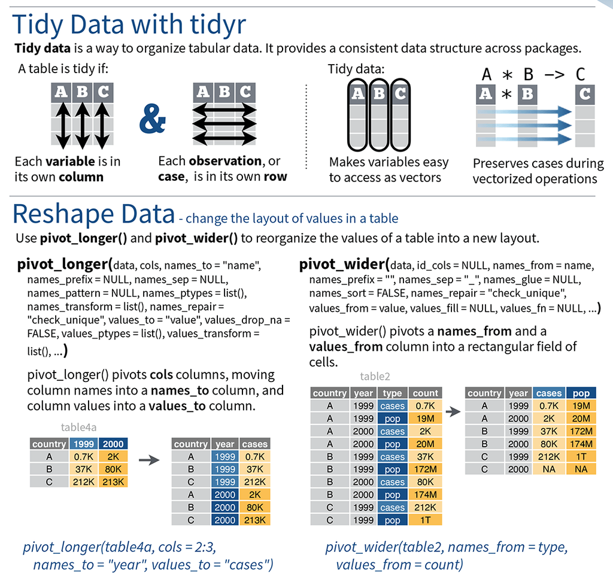

https://www.rstudio.com/resources/cheatsheets/ (Data Import Cheatsheet)

## `pivot_wider()` CANSIM

```r
revenue <- revenue_long %>%
  pivot_wider(names_from = REVENUE, values_from = Value)

revenue
```

```
## # A tibble: 165 x 34
##    Ref_Date GEO    `Total revenues` Federal `Social Sciences an~ `Health Canada`
##       <int> <chr>             <dbl>   <dbl>                <dbl>           <dbl>
##  1     2000 Canada         16224715 1554234               104306           41527
##  2     2001 Canada         17231250 1846138               109511           34669
##  3     2002 Canada         18488133 2223239               133368           43599
##  4     2003 Canada         21647925 2534964               178803           30157
##  5     2004 Canada         22687437 2635758               203082           30426
##  6     2005 Canada         24705347 2833294               221604           37168
##  7     2006 Canada         26458623 2874651               222010           42011
##  8     2007 Canada         27201804 3060336               220779           57051
##  9     2008 Canada         26405228 3075585               236172           36454
## 10     2009 Canada         31929458 3752740               250356           52515
## # ... with 155 more rows, and 28 more variables:
## #   Natural Sciences and Engineering Research Council <dbl>,
## #   Canadian Institute of Health Research <dbl>,
## #   Canada Foundation for Innovation <dbl>, Canada Research Chairs <dbl>,
## #   Other federal <dbl>, Non-federal <dbl>, Provincial <dbl>, Municipal <dbl>,
## #   Other provinces <dbl>, Foreign <dbl>, Tuition and other fees <dbl>,
## #   Credit courses tuiton <dbl>, Non-credit tution <dbl>, Other fees <dbl>, ...
```

## Visualizing

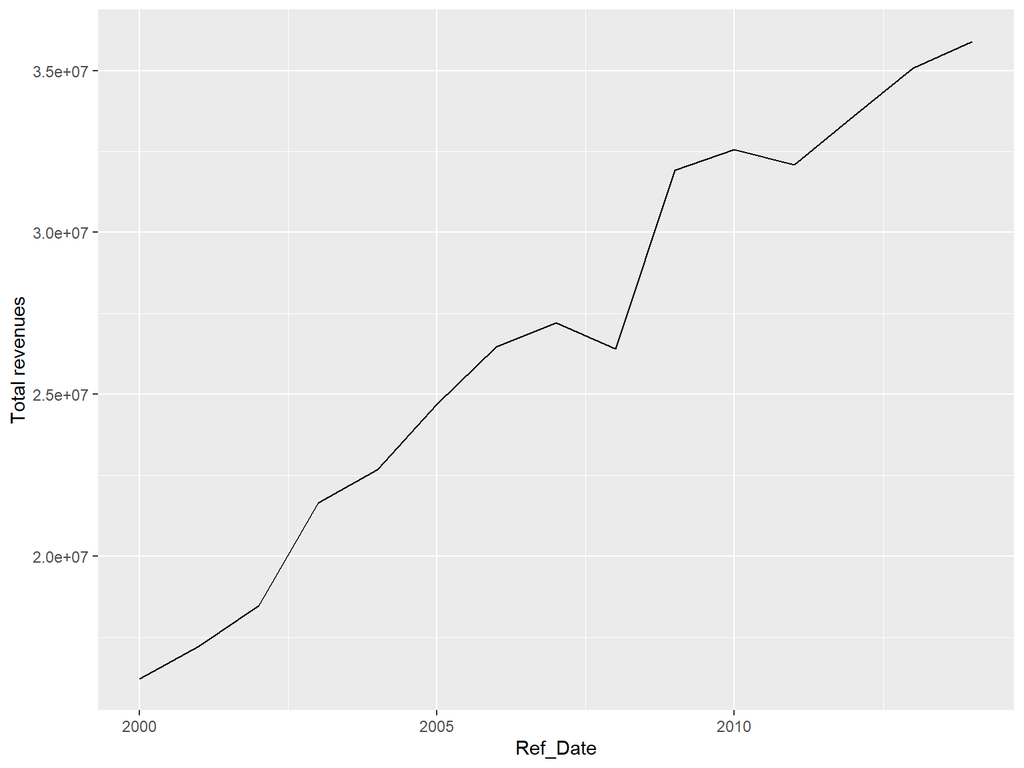

```r
revenue %>%
  filter(GEO == 'Canada') %>%
  # pass the result to ggplot() as the first argument
  ggplot(aes(Ref_Date, `Total revenues`)) +
  # now it switches to + to combine, which is ggplot's way
  geom_line()
```

Not the prettiest, but it works!

## Visualizing: Labels

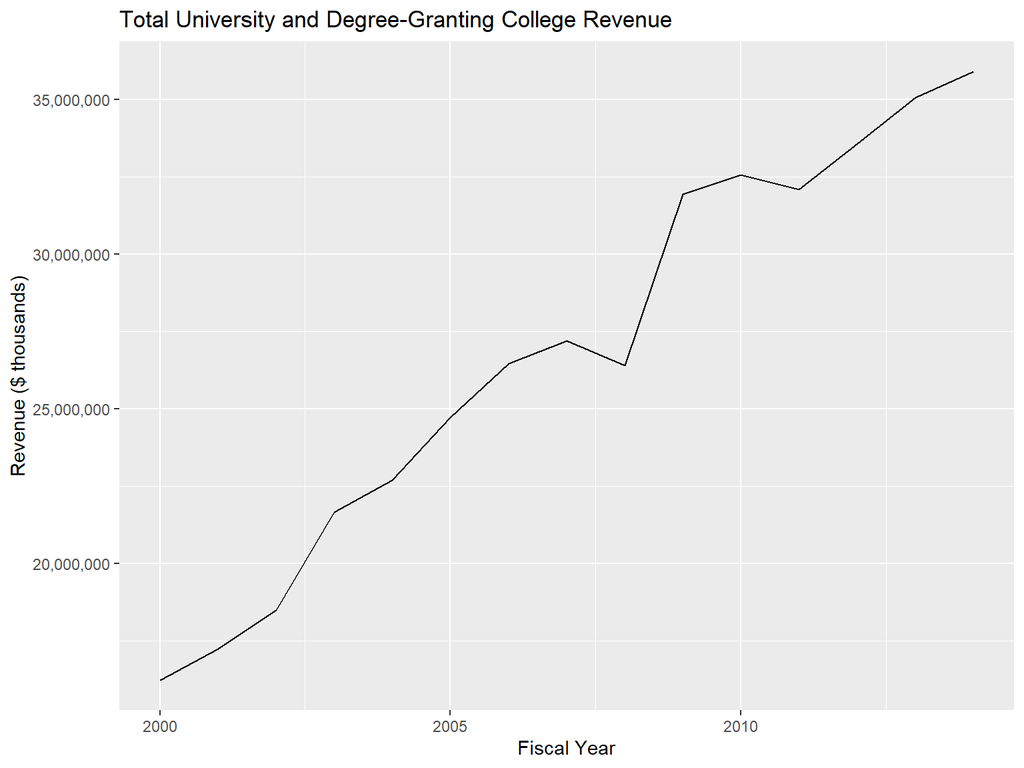

```r
revenue %>%
  filter(GEO == 'Canada') %>%
  ggplot(aes(Ref_Date, `Total revenues`)) +
  geom_line() +
  labs(title = 'Total University and Degree-Granting College Revenue',
       x = 'Fiscal Year',
       y = 'Revenue ($ thousands)') +
  scale_y_continuous(labels = scales::comma)
```

## Inline Calculation

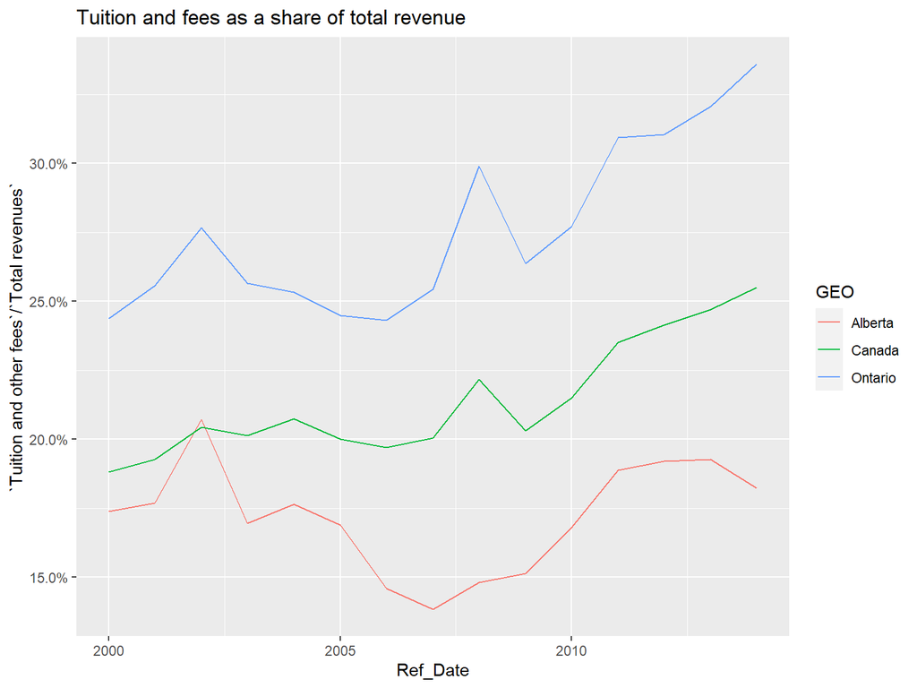

```r
revenue %>%
  filter(GEO %in% c('Canada', 'Alberta', 'Ontario')) %>%
  ggplot(aes(Ref_Date, `Tuition and other fees` / `Total revenues`, color = GEO)) +
  geom_line() +
  labs(title = 'Tuition and fees as a share of total revenue') +
  scale_y_continuous(labels = scales::percent)
```

## Exercises

1. Visualize another variable
2. Set some appropriate labels and scales
3. Graph a time subset (e.g., between 2005 and 2010)

## Other `dplyr` “verbs”

Which province took in the most tuition revenue in 2010?

```r
revenue %>%
  filter(GEO != 'Canada', Ref_Date == 2010) %>%
  select(GEO, `Tuition and other fees`) %>%
  arrange(desc(`Tuition and other fees`))
```

```
## # A tibble: 10 x 2
##    GEO                       `Tuition and other fees`
##    <chr>                                        <dbl>
##  1 Ontario                                    3563011
##  2 British Columbia                           1009476
##  3 Quebec                                      825943
##  4 Alberta                                     711973
##  5 Nova Scotia                                 305597
##  6 Manitoba                                    176165
##  7 Saskatchewan                                173600
##  8 New Brunswick                               146213
##  9 Newfoundland and Labrador                    61537
## 10 Prince Edward Island                         27878
```

## Create a new variable

```r
revenue %>%
  select(Ref_Date, GEO, `Tuition and other fees`, `Total revenues`) %>%
  mutate(tuition_share = `Tuition and other fees` / `Total revenues`)
```

```
## # A tibble: 165 x 5
##    Ref_Date GEO    `Tuition and other fees` `Total revenues` tuition_share
##       <int> <chr>                     <dbl>            <dbl>         <dbl>
##  1     2000 Canada                  3052960         16224715         0.188
##  2     2001 Canada                  3319524         17231250         0.193
##  3     2002 Canada                  3777453         18488133         0.204
##  4     2003 Canada                  4358013         21647925         0.201
##  5     2004 Canada                  4706894         22687437         0.207
##  6     2005 Canada                  4943699         24705347         0.200
##  7     2006 Canada                  5216088         26458623         0.197
##  8     2007 Canada                  5454375         27201804         0.201
##  9     2008 Canada                  5853354         26405228         0.222
## 10     2009 Canada                  6482539         31929458         0.203
## # ... with 155 more rows
```

Keeps the same number of rows

## Useful “mutations”

- Arithmetic: `+, -, *, /, ^`
- Modular arithmetic: `%/%` (integer division), `%%` (remainder)
- Logs: `log(), log2(), log10()`
- Offsets: `lead()`, `lag()`
- Cumulative and rolling aggregates: `cumsum()`, `cumprod()`, `cummin()`, `cummax()`, `cummean()`
- Logical comparisons: `<, <=, >, >=, !=, ==`
- Ranking: `min_rank()`, `row_number()`, `dense_rank()`, `percent_rank()`, `cume_dist()`, `ntile()`
- `ifelse()`
- `recode()`
- `case_when()`

## Summarize (aggregate)

```r
revenue %>%
  group_by(GEO) %>%
  summarise(avg_endowment_revenue = mean(Endowment)) %>%
  arrange(-avg_endowment_revenue)
```

```
## # A tibble: 11 x 2
##    GEO                       avg_endowment_revenue
##    <chr>                                     <dbl>
##  1 Canada                                  557090.
##  2 Ontario                                 230810.
##  3 Quebec                                   92153.
##  4 Alberta                                  84512.
##  5 British Columbia                         76689.
##  6 Nova Scotia                              29847.
##  7 Saskatchewan                             23139.
##  8 New Brunswick                            14813.
##  9 Newfoundland and Labrador                 2876.
## 10 Manitoba                                  1555.
## 11 Prince Edward Island                       696.
```

## Useful summarising functions:

- `mean(x)`, `median(x)`
- `sd(x)`, `IQR(x)` (interquartile range), `mad(x)` (median absolute deviation)
- `min(x)`, `max(x)`, `quantile(x, 0.25)`
- `first(x)`, `nth(x, 2)`, `last(x)`
- `n(x)`, `n_distinct(x)`
- Counts and proportions of logical values: `sum(x > 10)`, `mean(y == 0)`
  - `TRUE` is converted to `1` and `FALSE` to `0`

## Exercise:

Compute the total tuition revenue of the three western-most provinces in 2007.

```r
revenue %>%
  filter(GEO %in% c('British Columbia', 'Alberta', 'Saskatchewan'), Ref_Date == 2007) %>%
  summarise(sum(`Tuition and other fees`))
```

```
## # A tibble: 1 x 1
##   `sum(\`Tuition and other fees\`)`
##                               <dbl>
## 1                           1374509
```

## Group by new variable

These three provinces compared to all other provinces and national average.

```r
revenue %>%
  filter(Ref_Date == 2007) %>%
  mutate(category = case_when(
    GEO %in% c('British Columbia', 'Alberta', 'Saskatchewan') ~ '3 Western Provinces',
    GEO == 'Canada' ~ GEO,
    TRUE ~ 'All Other Provinces'
  )) %>%
  group_by(category) %>%
  summarise(sum(`Tuition and other fees`))
```

```
## # A tibble: 3 x 2
##   category            `sum(\`Tuition and other fees\`)`
##   <chr>                                           <dbl>
## 1 3 Western Provinces                           1374509
## 2 All Other Provinces                           4079866
## 3 Canada                                        5454375
```

## Change relative first year

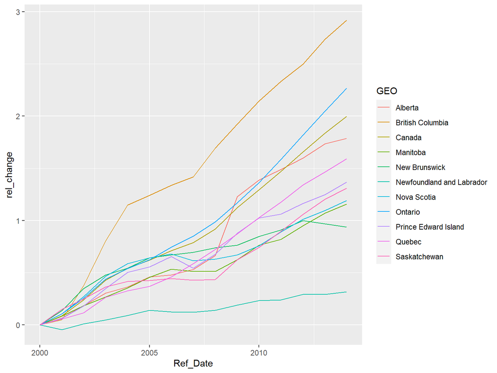

```r
tuition_relative_change <- revenue %>%
  arrange(Ref_Date, GEO) %>%
  group_by(GEO) %>%
  mutate(rel_change = (`Tuition and other fees` - first(`Tuition and other fees`)) / first(`Tuition and other fees`)) %>%
  select(Ref_Date, GEO, `Tuition and other fees`, rel_change)

ggplot(tuition_relative_change, aes(Ref_Date, rel_change, color = GEO)) +
  geom_line()
```

## Logical sums

Count years with positive endowment income by province

```r
revenue %>%
  group_by(GEO) %>%
  summarise(num_pos_endow = sum(Endowment > 0))
```

```
## # A tibble: 11 x 2
##    GEO                       num_pos_endow
##    <chr>                             <int>
##  1 Alberta                              12
##  2 British Columbia                     12
##  3 Canada                               12
##  4 Manitoba                             13
##  5 New Brunswick                        13
##  6 Newfoundland and Labrador            12
##  7 Nova Scotia                          13
##  8 Ontario                              12
##  9 Prince Edward Island                 12
## 10 Quebec                               15
## 11 Saskatchewan                         12
```

## Exercises

- Compare the Maritimes to the rest of Canada on one or more variable
- Between 2005 and 2007, which provinces received more than $100 M in Total grants?
- Which provinces, other than Nova Scotia and Ontario, had more than $20 M in Endowmennt income in 2003?
- Which province was in “third place” in total revenue in 2012?

## `purrr` (quickly)

(There’s a lot going on here, just in the slides for your quick reference.)

```r
revenue %>%
  filter(GEO != 'Canada') %>%
  group_by(Ref_Date) %>%
  summarise(revenue_quantiles = list(quantile(`Total revenues`, c(0.25, 0.5, 0.75)))) %>%
  mutate(
    low_25 = map_dbl(revenue_quantiles, "25%"),
    mid = map_dbl(revenue_quantiles, '50%'),
    high_75 = map_dbl(revenue_quantiles, '75%')
  )
```

```
## # A tibble: 15 x 5
##    Ref_Date revenue_quantiles  low_25      mid  high_75
##       <int> <list>              <dbl>    <dbl>    <dbl>
##  1     2000 <dbl [3]>         424965   681742. 1944551.
##  2     2001 <dbl [3]>         417664.  700424  2126550.
##  3     2002 <dbl [3]>         465112.  729434  2378510.
##  4     2003 <dbl [3]>         480404.  804636. 2708008.
##  5     2004 <dbl [3]>         530995.  853132. 2818174.
##  6     2005 <dbl [3]>         560023.  911819  3257599.
##  7     2006 <dbl [3]>         616412.  964536. 3320636.
##  8     2007 <dbl [3]>         592927.  944042. 3560364.
##  9     2008 <dbl [3]>         568461.  968932. 3404852.
## 10     2009 <dbl [3]>         741016. 1161066  4363439.
## 11     2010 <dbl [3]>         787082. 1213456  4436956.
## 12     2011 <dbl [3]>         775059. 1169906. 4177081
## 13     2012 <dbl [3]>         799797. 1240542  4296184.
## 14     2013 <dbl [3]>         791843. 1298845  4437751.
## 15     2014 <dbl [3]>         799297. 1316785  4623504.
```

# Vectors (and other types)

## Missing data

```r
NA > 5
```

```
## [1] NA
```

```r
10 == NA
```

```
## [1] NA
```

```r
NA + 10
```

```
## [1] NA
```

What about this?

```
NA / 2
```

## Filtering and NAs

```r
x <- NA
is.na(x)
```

```
## [1] TRUE
```

`filter()` only includes rows where the condition is `TRUE`; it excludes both `FALSE` and `NA` values. If you want to preserve missing values, ask for them explicitly:

```r
test_data <- tibble(x = c(1, NA, 3))
filter(test_data, x > 1)
```

```
## # A tibble: 1 x 1
##       x
##   <dbl>
## 1     3
```

```r
filter(test_data, is.na(x) | x > 1)
```

```
## # A tibble: 2 x 1
##       x
##   <dbl>
## 1    NA
## 2     3
```

## Dealing with vectors…

```r
c(1, 2, 3)
```

```
## [1] 1 2 3
```

```r
1:3
```

```
## [1] 1 2 3
```

## Dealing with vectors…

```r
1:3 + 1:9
```

```
## [1]  2  4  6  5  7  9  8 10 12
```

What about…

```
1:3 + 1:10
```

## Dealing with vectors…

```r
1:3 + 1:10
```

```
##  [1]  2  4  6  5  7  9  8 10 12 11
```

What happened?

## Missing values

```r
mean(c(1,2,3))
```

```
## [1] 2
```

What do we expect here?

```
mean(c(1,NA,3))
```

## Missing values

```r
mean(c(1,NA,3))
```

```
## [1] NA
```

```r
mean(c(1,NA,3), na.rm = TRUE)
```

```
## [1] 2
```

## Vectors

## Vectors

- Coercion (explicit and implicit)
  - Type hierarchy
- Atomic vectors (homogenous) vs lists (can nest/heterogeneous)
- Names
- Subsetting

## Vectors: Naming

```r
c(x = 1, y = 2, z = 4)
```

```
## x y z
## 1 2 4
```

```r
set_names(1:3, c("a", "b", "c"))
```

```
## a b c
## 1 2 3
```

## Vectors: Subsetting

```r
# positive values
x <- c("one", "two", "three", "four", "five")
x[c(3, 2, 5)]
```

```
## [1] "three" "two"   "five"
```

```r
# negative values
x[c(-1, -3, -5)]
```

```
## [1] "two"  "four"
```

```
#> [1] "two"  "four"
```

```r
# subset a named vector w/character vector
x <- c(abc = 1, def = 2, xyz = 5)
x[c("xyz", "def")]
```

```
## xyz def
##   5   2
```

## Vectors: Logical subsetting

```r
x <- c(10, 3, NA, 5, 8, 1, NA)

# All non-missing values of x
x[!is.na(x)]
```

```
## [1] 10  3  5  8  1
```

```
#> [1] 10  3  5  8  1
```

```r
# All even (or missing!) values of x
x[x %% 2 == 0]
```

```
## [1] 10 NA  8 NA
```

```
#> [1] 10 NA  8 NA
```

## Lists

```r
x <- list(1, 2, 3)
x
```

```
## [[1]]
## [1] 1
##
## [[2]]
## [1] 2
##
## [[3]]
## [1] 3
```

```r
str(x) # str...ucture
```

```
## List of 3
##  $ : num 1
##  $ : num 2
##  $ : num 3
```

## Lists: Can contain different types of objects:

```r
y <- list("a", 1L, 1.5, TRUE)
str(y)
```

```
## List of 4
##  $ : chr "a"
##  $ : int 1
##  $ : num 1.5
##  $ : logi TRUE
```

## Lists: Or other lists:

```r
z <- list(list(1, 2), list(3, 4))
str(z)
```

```
## List of 2
##  $ :List of 2
##   ..$ : num 1
##   ..$ : num 2
##  $ :List of 2
##   ..$ : num 3
##   ..$ : num 4
```

# Statistics with R

- Large library of built-in statistics functions.
- Just about any statistics function is available as a package.
- Don’t always follow the tidyverse conventions.

## Vectors

```r
mtcars$mpg
```

```
##  [1] 21.0 21.0 22.8 21.4 18.7 18.1 14.3 24.4 22.8 19.2 17.8 16.4 17.3 15.2 10.4
## [16] 10.4 14.7 32.4 30.4 33.9 21.5 15.5 15.2 13.3 19.2 27.3 26.0 30.4 15.8 19.7
## [31] 15.0 21.4
```

```r
mtcars %>% pull(mpg)
```

```
##  [1] 21.0 21.0 22.8 21.4 18.7 18.1 14.3 24.4 22.8 19.2 17.8 16.4 17.3 15.2 10.4
## [16] 10.4 14.7 32.4 30.4 33.9 21.5 15.5 15.2 13.3 19.2 27.3 26.0 30.4 15.8 19.7
## [31] 15.0 21.4
```

## Statistics with Vectors

- `mean(mtcars$mpg)`
- `mean(mtcars$mpg, trim = .1)`
- `table(iris$Species)`
- `iris %>% group_by(Species) %>% tally()`
- `hist(mtcars$mpg)`
- `ggplot(mtcars) + geom_histogram(aes(x = mpg))`
- `ggplot(mtcars) + geom_histogram(aex(x = mpg)) + facet_grid(~vs)`

## Broadcasting

```r
mtcars$mpg - mean(mtcars$mpg)
```

```
##  [1]  0.909375  0.909375  2.709375  1.309375 -1.390625 -1.990625 -5.790625
##  [8]  4.309375  2.709375 -0.890625 -2.290625 -3.690625 -2.790625 -4.890625
## [15] -9.690625 -9.690625 -5.390625 12.309375 10.309375 13.809375  1.409375
## [22] -4.590625 -4.890625 -6.790625 -0.890625  7.209375  5.909375 10.309375
## [29] -4.290625 -0.390625 -5.090625  1.309375
```

## *t*-tests

```r
t.test(disp ~ vs, data = mtcars)
```

```
##
##  Welch Two Sample t-test
##
## data:  disp by vs
## t = 5.9416, df = 26.977, p-value = 2.477e-06
## alternative hypothesis: true difference in means between group 0 and group 1 is not equal to 0
## 95 percent confidence interval:
##  114.3628 235.0229
## sample estimates:
## mean in group 0 mean in group 1
##        307.1500        132.4571
```

## Correlation

```r
cor.test(mtcars$disp, mtcars$vs)
```

```
##
##  Pearson's product-moment correlation
##
## data:  mtcars$disp and mtcars$vs
## t = -5.5289, df = 30, p-value = 5.235e-06
## alternative hypothesis: true correlation is not equal to 0
## 95 percent confidence interval:
##  -0.8488377 -0.4808327
## sample estimates:
##        cor
## -0.7104159
```

## Chi Squared (1)

Smoking and Exercise

```r
library(MASS)
tbl <- table(survey$Smoke, survey$Exer)
tbl
```

```
##
##         Freq None Some
##   Heavy    7    1    3
##   Never   87   18   84
##   Occas   12    3    4
##   Regul    9    1    7
```

## Chi Squared (2)

```r
chisq.test(tbl)
```

```
##
##  Pearson's Chi-squared test
##
## data:  tbl
## X-squared = 5.4885, df = 6, p-value = 0.4828
```

## More Stats

- `modeOf()`
- `maxFreq()`
- `max()`, `min()` and `range()`
- `IQR()`, `quantile()`, `quantile( x = data, probs = c(.25, .75)`

# Modeling

When we have the data the way we want it, we want to ask questions about it. To determine the relationship between parts of the data.

This can range from exploratory modeling (to better understand the data) to more formally trying to establish relationships between variables. The process is the same for both, but the mindset is different.

## Types of Modeling

- define a family of models - expressed as an equation - you are trying to estimate the **parameters** of the question
- generate a fitted model that fills in the parameters

### The goal

You are trying to get the model from the family that best fits the data. That doesn’t mean it’s a “good” or “true” model.

## Simulated Data

The `modelr` package has a simulated dataset called `sim1`.

```r
library(modelr)
sim1$x
```

```
##  [1]  1  1  1  2  2  2  3  3  3  4  4  4  5  5  5  6  6  6  7  7  7  8  8  8  9
## [26]  9  9 10 10 10
```

## Plotting `sim1`

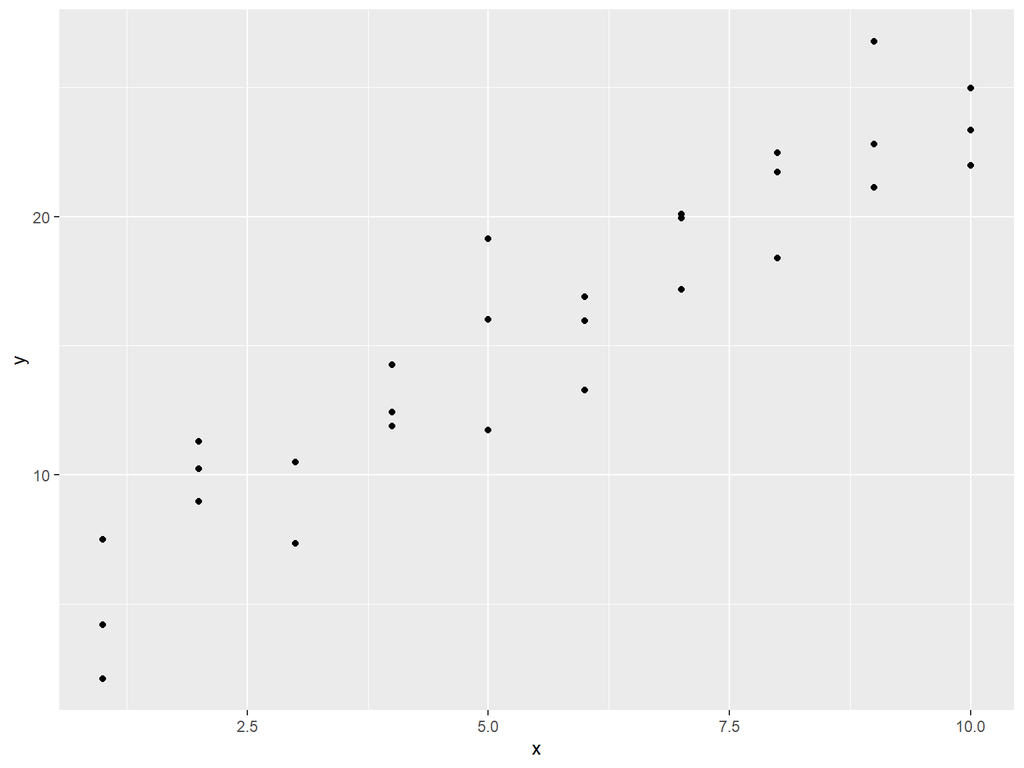

```r
ggplot(sim1, aes(x, y)) +
  geom_point()
```

## Plotting `sim1`

[figure not shown]

- we can see that there is a pattern from the scatter plot

## R can do all of this in 1 command

Of course, R has a tool to do this whole process automatically. This is our standard OLS regression.

```r
sim1_mod <- lm(y ~ x, data = sim1)
coef(sim1_mod)
```

```
## (Intercept)           x
##    4.220822    2.051533
```

## Generate Predictions

We can use a model object like `sim1_mod` to generate predictions. We an start with an empty grid.

```r
grid <- sim1 %>%
  data_grid(x)
grid
```

```
## # A tibble: 10 x 1
##        x
##    <int>
##  1     1
##  2     2
##  3     3
##  4     4
##  5     5
##  6     6
##  7     7
##  8     8
##  9     9
## 10    10
```

## Generate Predictions (2)

```r
grid <- grid %>%
  add_predictions(sim1_mod)
grid
```

```
## # A tibble: 10 x 2
##        x  pred
##    <int> <dbl>
##  1     1  6.27
##  2     2  8.32
##  3     3 10.4
##  4     4 12.4
##  5     5 14.5
##  6     6 16.5
##  7     7 18.6
##  8     8 20.6
##  9     9 22.7
## 10    10 24.7
```

## Plot those predictions using `geom_line`.

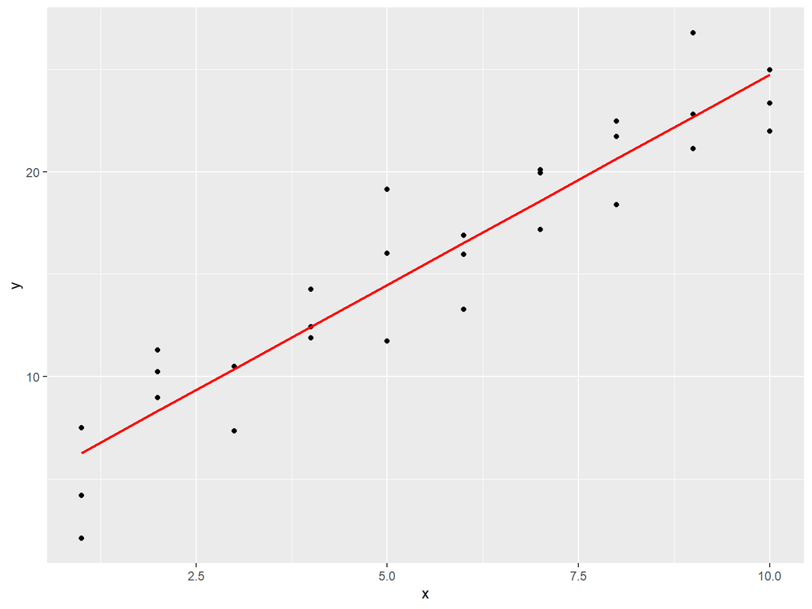

```r
ggplot(sim1, aes(x)) +
  geom_point(aes(y = y)) +
  geom_line(aes(y = pred), data = grid, colour = "red", size = 1)
```

## Add residuals

Add residuals. We need to use the original dataset.

```r
sim1 <- sim1 %>%
  add_residuals(sim1_mod)
sim1
```

```
## # A tibble: 30 x 3
##        x     y    resid
##    <int> <dbl>    <dbl>
##  1     1  4.20 -2.07
##  2     1  7.51  1.24
##  3     1  2.13 -4.15
##  4     2  8.99  0.665
##  5     2 10.2   1.92
##  6     2 11.3   2.97
##  7     3  7.36 -3.02
##  8     3 10.5   0.130
##  9     3 10.5   0.136
## 10     4 12.4   0.00763
## # ... with 20 more rows
```

## Plot Residuals

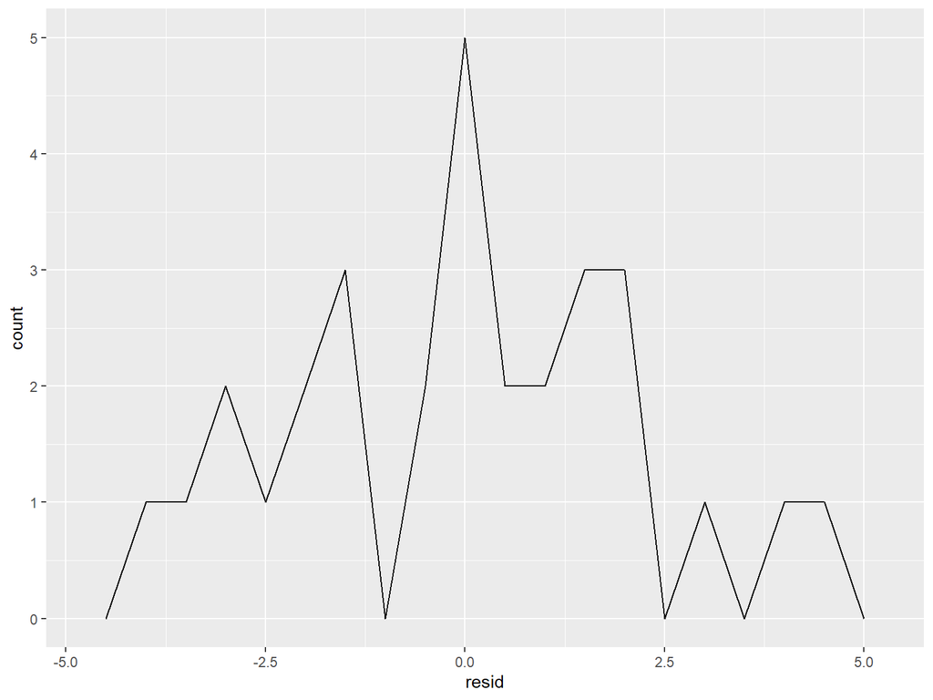

```r
ggplot(sim1, aes(resid)) +
  geom_freqpoly(binwidth = 0.5)
```

## Plot Residuals

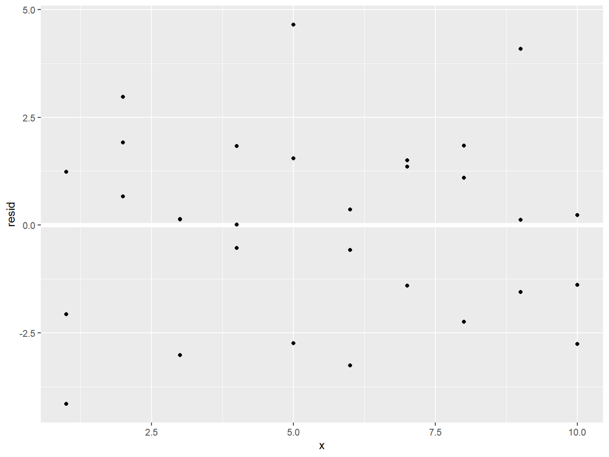

```r
ggplot(sim1, aes(x, resid)) +
  geom_ref_line(h = 0) +
  geom_point()
```

# Capstone Exercise

The DC BikeShare Dataset has the number of bike share rides on each particularly day or time. There are two datasets: one with the total number of rides per day and one with the number of rides per hour.

Also included with the data is the weather.

## Thy these

Things to try:

1. Find some outliers and why they happened (try googling specific dates).
2. Estimate the effect that the seasons have on bike share usage? Day of the week?
3. Build a model that predicts bike share usage for a given day. Separate your data into three parts.

## Notes

- The R formula language – using concepts from how the Tidyverse handles fields.
  - `data = .`
  - describe how to go from equations to R formulas - the `~` is the `=` we would write in an equation. `y ~ x` translates to `y = a_1 + a_2 * x`
  - `model_matrix` function
  - categorical variables – does that mean we have to deal with factors?
- statistical testings `t.test` - use the formula language – come up with examples.
- modeling using `lm` - also use the formula language

# Additional Resources

## Online Resources

Start here:

- http://r4ds.had.co.nz/
- http://stat545.com/

Additional:

- http://adv-r.had.co.nz/
- http://r-pkgs.had.co.nz/
- http://swcarpentry.github.io/r-novice-inflammation/
- https://rstudio-education.github.io/hopr/preface.html

For help/community:

- http://stackoverflow.com/questions/tagged/r
- https://twitter.com/search?q=%23rstats
- https://www.r-project.org/mail.html (Though they’re not terribly welcoming to newbies sometimes…)

## Print Books

- https://us.sagepub.com/en-us/nam/discovering-statistics-using-r/book236067%20
- https://us.sagepub.com/en-us/nam/an-r-companion-to-applied-regression/book233899
- http://shop.oreilly.com/product/0636920028574.do

## References

- Wickham, Hadley (2014). https://www.jstatsoft.org/article/view/v059i10